# Jensen Collaboration

Brian Gural

4/13/2023

## Load data and packages

After loading our data and packages, we perform dimensional reduction and exclude low-quality clusters:

After loading our data and packages, we perform dimensional reduction. We’ll exclude nuclei above 1% mitocondrial gene expression.

```r
sn.clust <- ClusterSeurat(sn, max.rna.ft = 4000,
                          max.mt.pt = 1, res = 0.015)
```

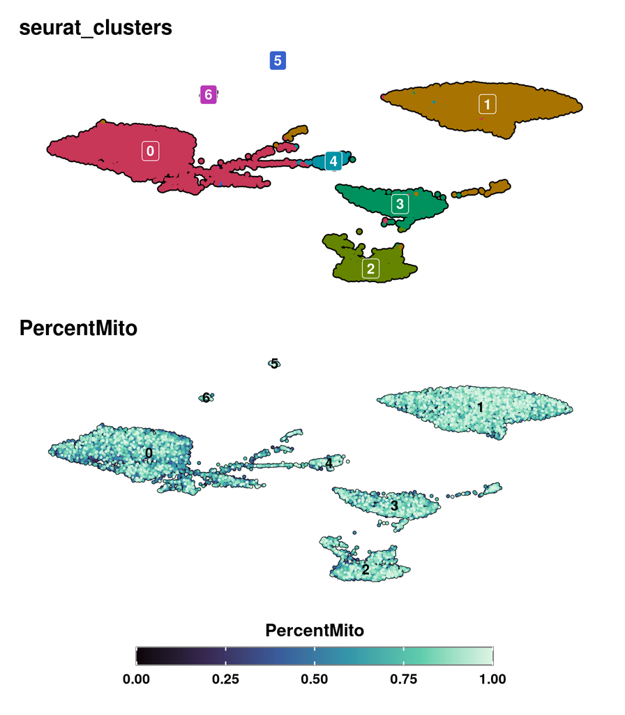

We can annotate these clusters into cell types in a few ways. I’ve been finding the markers with Seurat::FindMarkers(). In this pipeline, we looked for markers that are expressed >1.5x more in a cluster and in >25% of the nuclei

**MuSiC and composition estimates**  
As I use it, MuSiC takes our single nucleus clusters and looks for deconvolution markers itself. It prioritizes markers that are expressed in most of the nuclei in a given cluster, consistant within the cluster, and variable between all of the clusters. It is also possible for us to supply our own markers.

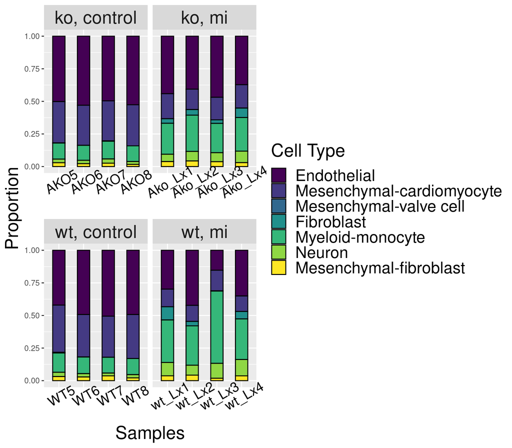